# Distributions

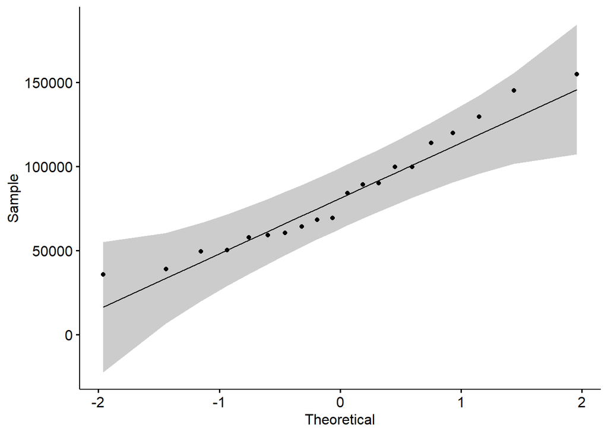

```r
ggqqplot(cp6)
```

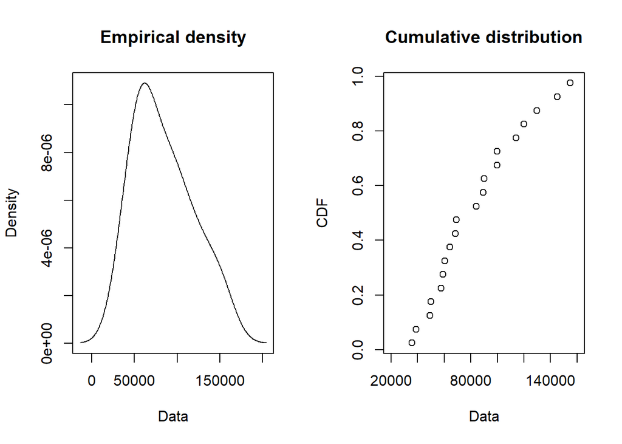

```r
plotdist(cp6, histo= FALSE, demp = TRUE)
```

```r
shapiro.test(cp6)
```

```
##
##  Shapiro-Wilk normality test
##
## data:  cp6
## W = 0.94452, p-value = 0.2914
```

```r
ad.test(cp6)
```

```
##
##  Anderson-Darling normality test
##
## data:  cp6
## A = 0.39481, p-value = 0.3401
```

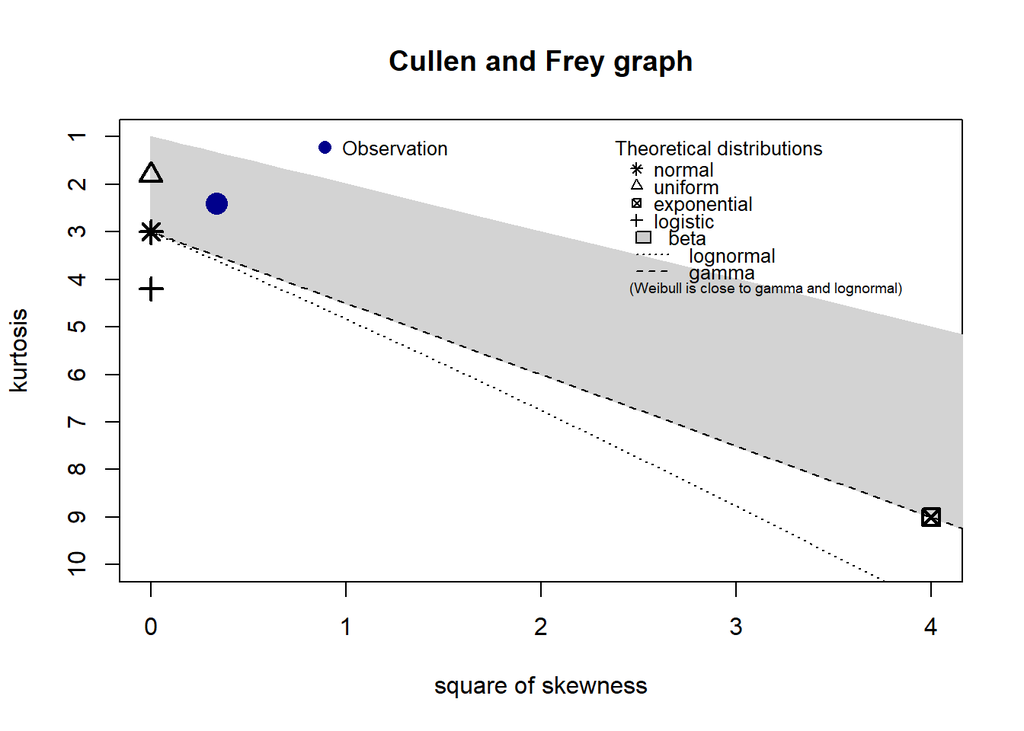

```
## summary statistics
## ------
## min:  35745   max:  154879
## median:  76673.5
## mean:  83971.25
## estimated sd:  34813.22
## estimated skewness:  0.5788089
## estimated kurtosis:  2.409776
```

```r
descdist(data =cp6, discrete =FALSE)
```

```r
lcp6=fitdist(cp6,"lnorm")
```

#### Conclusion: CP6 ~ LogNormal(mean= 11.255 , sd=0.413), en d’autre termes log(CP2) ~ N(mean= 11.255 , sd=0.413).

# Total des capitaux propre: TCP

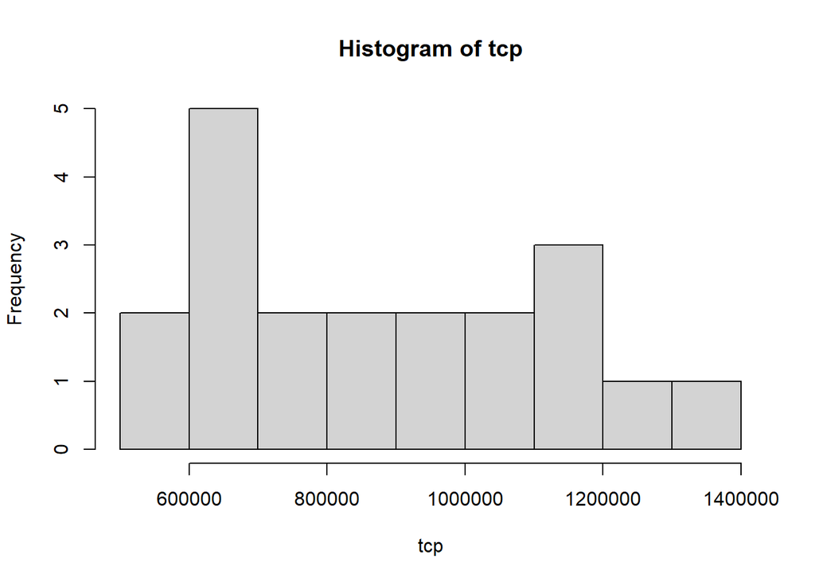

```r
tcp<-b$tcp
hist(tcp)
```

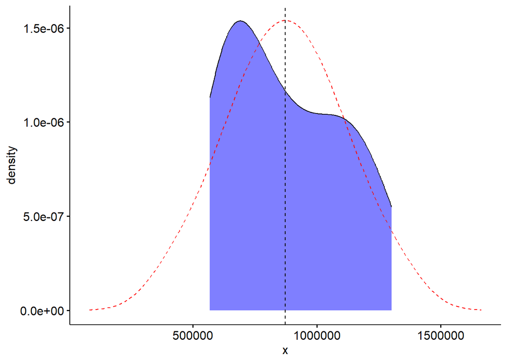

```r
ggdensity(tcp, add='mean', fill='blue')+stat_overlay_normal_density(color = "red", linetype = "dashed")
```

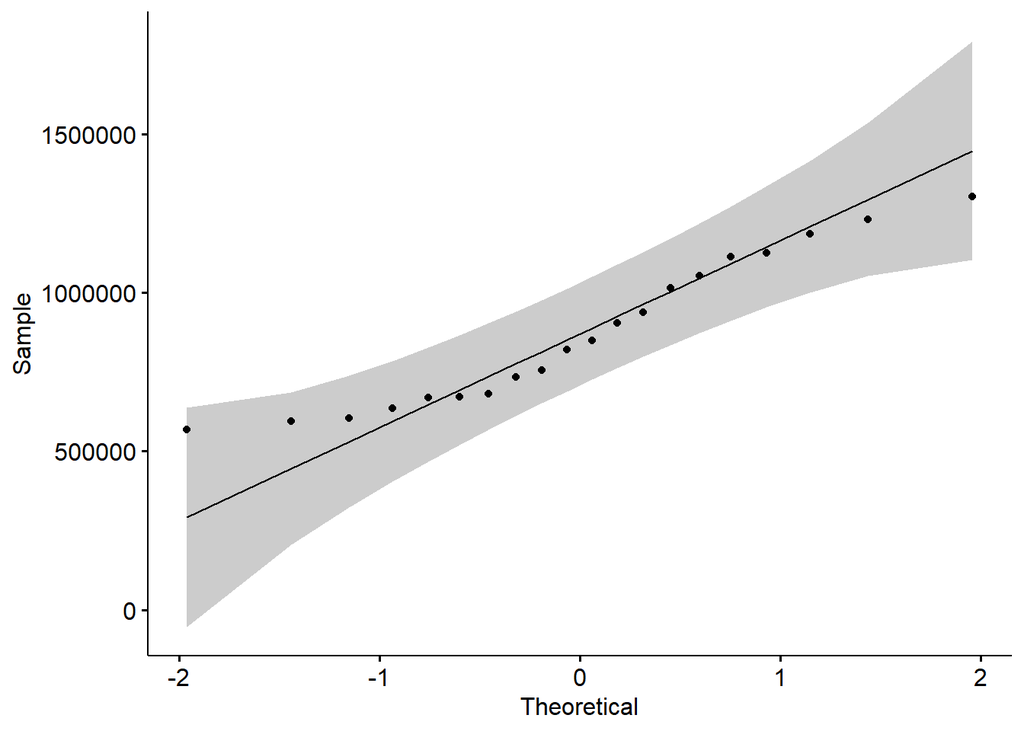

```r
ggqqplot(tcp)
```

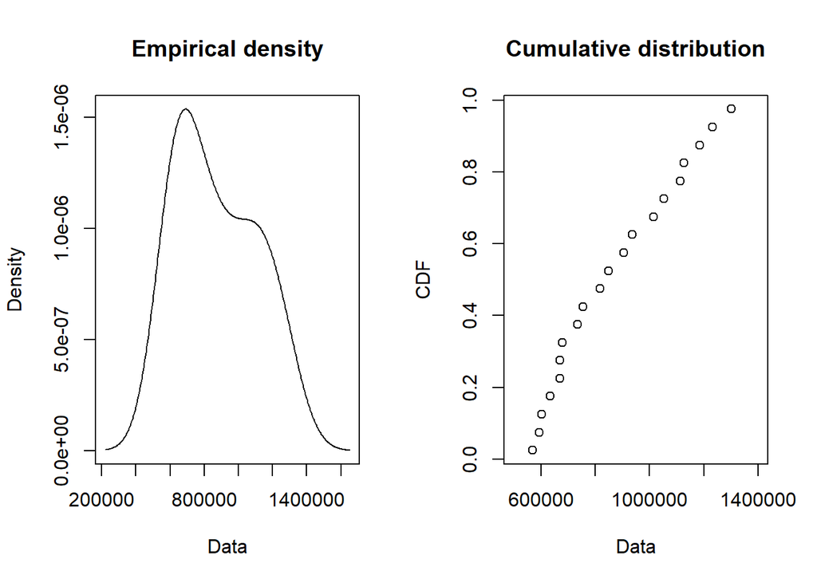

```r
plotdist(tcp, histo= FALSE, demp = TRUE)
```

```r
shapiro.test(tcp)
```

```
##
##  Shapiro-Wilk normality test
##
## data:  tcp
## W = 0.9269, p-value = 0.1346
```

```r
ad.test(tcp)
```

```
##
##  Anderson-Darling normality test
##
## data:  tcp
## A = 0.50493, p-value = 0.1793
```

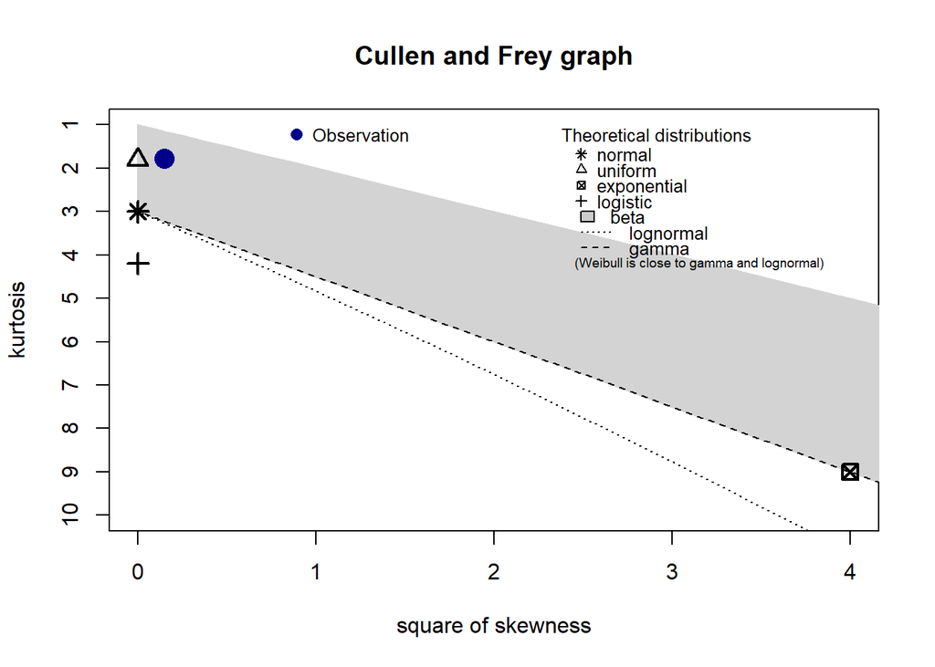

```
## summary statistics
## ------
## min:  568459   max:  1302173
## median:  834298.5
## mean:  872605.4
## estimated sd:  234648.2
## estimated skewness:  0.3861855
## estimated kurtosis:  1.786421
```

```r
descdist(data =tcp, discrete =FALSE)
```

#### Conclusion: TCP ~ 3-parameter weibull (shape=1,14583, scale=320554, thres=565339)

#### On pourra aussi appliquer la transformation de BoxCox; $\lambda= -0.5$ (minitab) sur la variable TCP pour la normaliser.

# Total bilan: TB

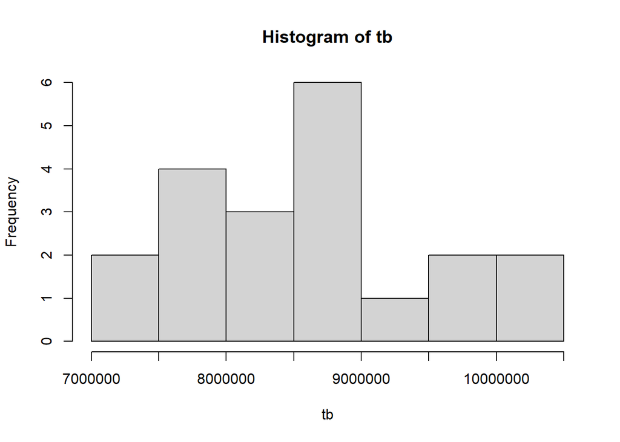

```r
tb<-b$tb
hist(tb)
```

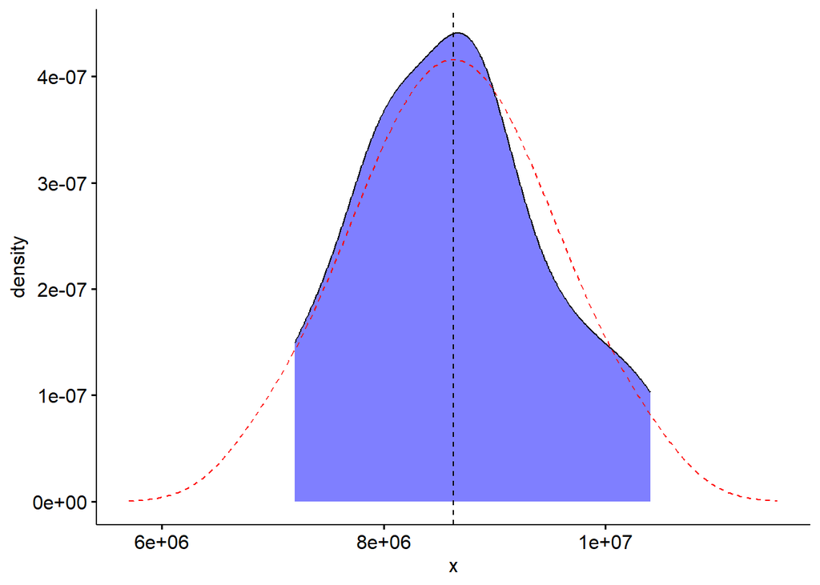

```r
ggdensity(tb, add='mean', fill='blue')+stat_overlay_normal_density(color = "red", linetype = "dashed")
```

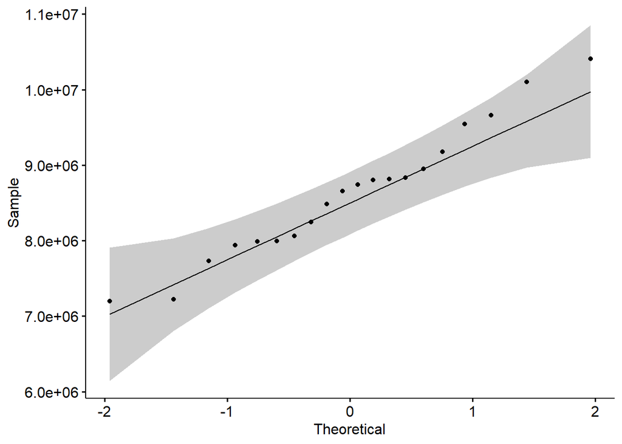

```r
ggqqplot(tb)
```

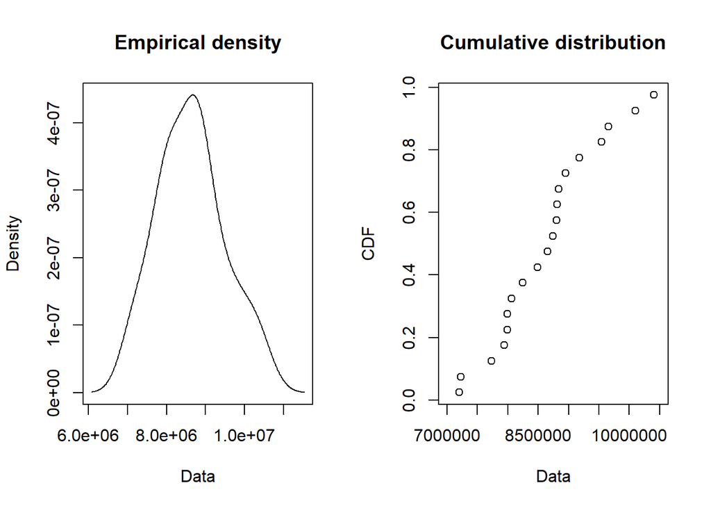

```r
plotdist(tb, histo= FALSE, demp = TRUE)
```

```r
shapiro.test(tb)
```

```
##
##  Shapiro-Wilk normality test
##
## data:  tb
## W = 0.97101, p-value = 0.7761
```

```r
ad.test(tb)
```

```
##
##  Anderson-Darling normality test
##
## data:  tb
## A = 0.23154, p-value = 0.7719
```

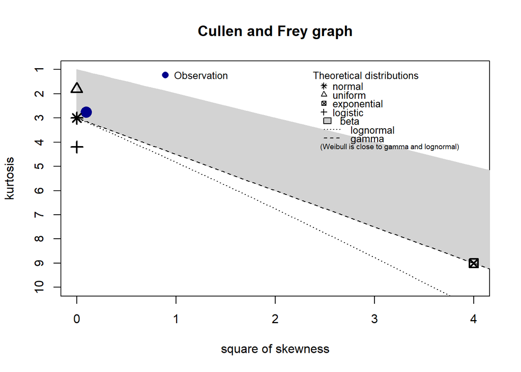

```
## summary statistics
## ------
## min:  7198614   max:  10406770
## median:  8697893
## mean:  8628326
## estimated sd:  868861.5
## estimated skewness:  0.305677
## estimated kurtosis:  2.758765
```

```r
descdist(data =tb, discrete =FALSE)
```

```r
ntb=fitdist(tb,"norm")
```

#### les tests de normalité de TB sont très bons TB ~ N(mean= 8628326 ,sd= 846861)

#### On pourra aussi appliquer la transformation de BoxCox; $= -0.5 $ (minitab) sur la variable TB pour la normaliser.

# Tableau récapitulatif

| Variables | Distributions | Autres distributions et transformations de normalisation |
| --- | --- | --- |
| AC12 | 3-parameter weibull (shape=1,27236, scale=341964, thres=229170) | N(mean=548453.8,sd=227332.1) |
| AC3 | logistic (μ=5982000,s=164391) | BoxCox transformation (λ=−3) |
| AC45 | 3-parameter weibull (shape=1359,84798, scale=457094000, thres=-455148000) | BoxCox transformation (λ=2) |
| AC6 | 3-parameters weibull (shape=0,82878, scale=61604,88454, thres=107917). | Johnson tranformation 1.14174 + 0.522007*log( ( ac6 - 109374 ) / ( 424867 - ac6 ) ) |
| AC7 | — | Johnson transformation 0.0375501+0.478592*log((ac7-61348.7)/(236502-ac7)) |
| PA12 | N(mean=1098202,sd=265476) | — |
| PA3 | 3-parameters weibull (shape=1,47545, scale=902426, thres= 4738030) | Johnson transformation pa3-1.88580 +1.37143 * asinh((pa3-4805082) / 299124) |
| PA4 | N(mean= 897246 ,sd=49134) | — |
| PA5 | N(mean= 205305 ,sd=36894) | — |
| TP | N(mean= 7755721 ,sd= 630389) | — |
| CP1 | CP1= 132 405 | — |
| CP2 | LogNormal(mean= 13.344 , sd=0.318) | — |
| CP4 | CP1= 423 | — |
| CP5 | Mixture distribution: N1 ($\mu_1$ = 3.375025, $\sigma_1$ = 1.932439, $\lambda_1$ = 0.7999767) N2 ($\mu_2$ = 18556.336954, $\sigma_2$ = 18532.502611, $\lambda_2$ = 0.2000233) | — |
| CP6 | LogNormal(mean= 11.255 , sd=0.413) | — |
| TCP | 3-parameter weibull (shape=1,14583,scale=320554,thres=565339) | BoxCox transformation (λ=-0.5) |
| TB | N(mean= 8628326 ,sd= 846861) | BoxCox transformation (λ=-0.5) |

## ANNEXE

### The Weibull distribution:

The probability density function (PDF) f is given by :

$$f(x; \lambda, k) = \frac{k}{\lambda}
\left(\frac{x}{\lambda}\right)^{k-1} e^{-(x/\lambda)^k}$$

Where:

- $\lambda$ is the scale parameter.
- $k$ is the shape parameter.

### The 3-parameter Weibull distribution:

The probability density function (PDF) f is given by :

$$f(x; \alpha, \beta, \gamma) = \frac{\beta}{\alpha} \left(\frac{x -
\gamma}{\alpha}\right)^{\beta - 1} \exp\left[-\left(\frac{x -
\gamma}{\alpha}\right)^{\beta}\right]$$
Where:

- $\alpha$ is the scale parameter.
- $\beta$ is the shape parameter.
- $\gamma$ is the threshold (location) parameter.

### The logistic distribution:

The probability density function (PDF) f is given by :

$$f(x; \mu, s) = \frac{1}{s} \cdot \frac{e^{-(x - \mu)/s}}{(1 + e^{-(x -
\mu)/s})^2}$$

Where:

- $\mu$ is the location parameter.
- $s$ is the scale parameter.

### The log-logistic distribution:

$$X \sim \text{L-Logis}(\mu, s)
\leftrightarrow \log(X) \sim \text{Logis}(\mu, s)$$

#On pourra utiliser le dashbord shiny pour ajuster les variables de manières interactive

```r
#fitur::fit_dist_addin()
```